# Serious Incidents in Philadelphia Schools during SY18-19

Jin Chen

7/22/2020

I first begin by loading tidyverse and readxl, the two packages we will be using. I then define the url for the data source as url and the destination file as destfile. I then load the excel sheet and save it as the incidents_df data frame.

```r
library(tidyverse)
library(readxl)

url <- "https://cdn.philasd.org/offices/performance/Open_Data/School_Performance/Serious_Incidents/School%20Profiles%20Serious%20Incidents%202018-2019.xlsx"
destfile <- "../data/SY18-19.xlsx"
download.file(url, destfile, mode = "wb")

incidents_df <- read_excel(destfile, sheet = 1)
```

```r
bytype <- incidents_df %>%
  group_by(INCIDENT_TYPE) %>%
  summarize( Total = sum(INCIDENT_COUNT)) %>%
  arrange(desc(Total)) %>%
  ungroup()
```

This quick analysis can be seen much better in a bar chart.

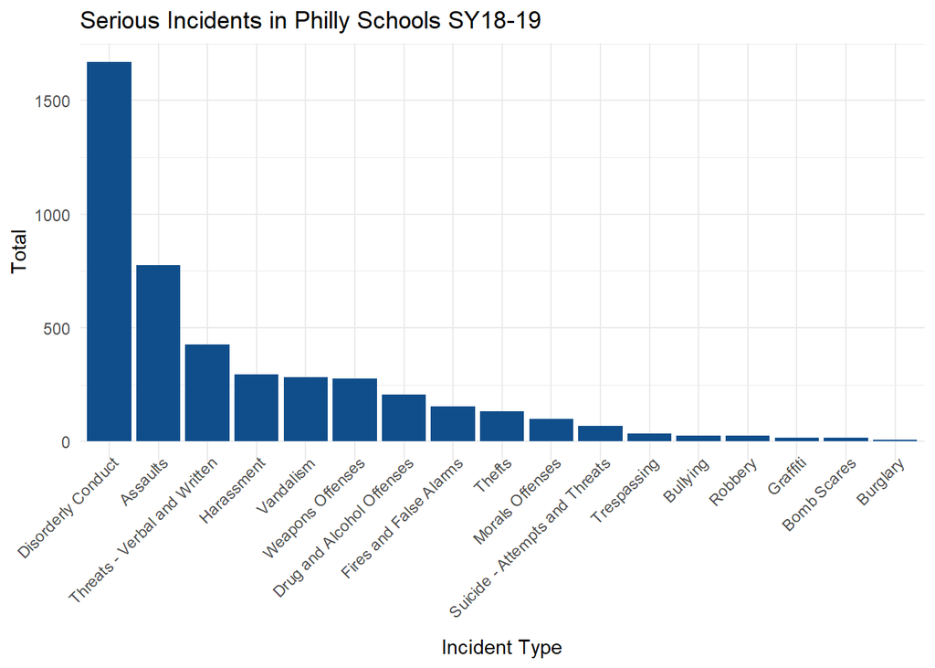

```r
ggplot(data = bytype, aes(x = reorder(INCIDENT_TYPE, -Total),y = Total)) +
  geom_bar(stat = "identity", fill = "dodgerblue4") +
  theme_minimal() +
  labs(title = "Serious Incidents in Philly Schools SY18-19",
      x = "Incident Type") +
  theme(axis.text.x = element_text(angle = 45, vjust = 1.1, hjust = 1.0))
```

Thus ends my initial exploration into this data file. The School District of Philadelphia (SDP) also provides historical data on serious incidents which I may look into next. I can also explore incidents by school using the “SCHOOL_ID” identifier by joining a dataset with that ID corresponding with the school name.

**Potential future questions**

2.Has serious incidents been increasing or decreasing in SDP schools?

3.Do some schools have more reported incidents than others?

4.How have some schools performed historically in serious incidents? For example, have some schools been decreasing and others increasing?

5.Is there any correlation between number of serious incidents and other factors such as attendance and graduation rates?